# Lab 10 - Polynomial and step regression

Nonparametric statistics ay 2022/2023

2022/10/28

## Loading necessary libraries

```r
library(ISLR2)
library(car)
```

## Nonparametric Regression

Let us familiarize with the dataset we will be using. It is something you should remember quite well: the Wage dataset by the amazing An Introduction to Statistical Learning book, since August 2021 at its second (and free!) edition available [here](https://www.statlearning.com). It contains wage and other data for a group of 3000 male workers in the Mid-Atlantic region. For the moment, let us focus on the Wage and age variables only.

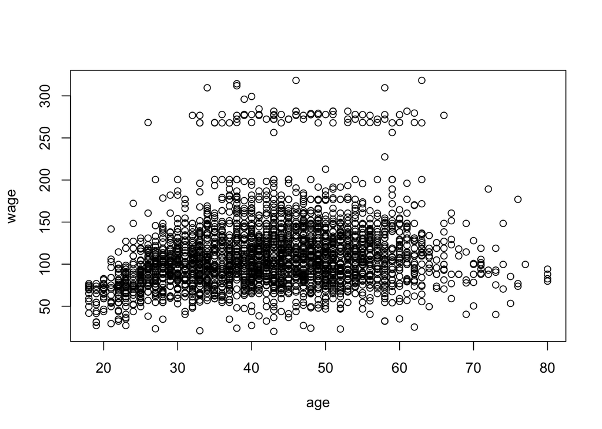

```r
data(Wage)
wage <- Wage$wage
age <- Wage$age
plot(age, wage)
```

We have a “weird” cluster of people with a VERY high wage and we observe some kind of reverse bathtub behavior. What happens if I try to model it linearly?

```r
m_linear=lm(wage ~ age)
summary(m_linear)
```

```
##
## Call:
## lm(formula = wage ~ age)
##
## Residuals:
##      Min       1Q   Median       3Q      Max
## -100.265  -25.115   -6.063   16.601  205.748
##
## Coefficients:
##             Estimate Std. Error t value Pr(>|t|)
## (Intercept) 81.70474    2.84624   28.71   <2e-16 ***
## age          0.70728    0.06475   10.92   <2e-16 ***
## ---
## Signif. codes:  0 '***' 0.001 '**' 0.01 '*' 0.05 '.' 0.1 ' ' 1
##
## Residual standard error: 40.93 on 2998 degrees of freedom
## Multiple R-squared:  0.03827,    Adjusted R-squared:  0.03795
## F-statistic: 119.3 on 1 and 2998 DF,  p-value: < 2.2e-16
```

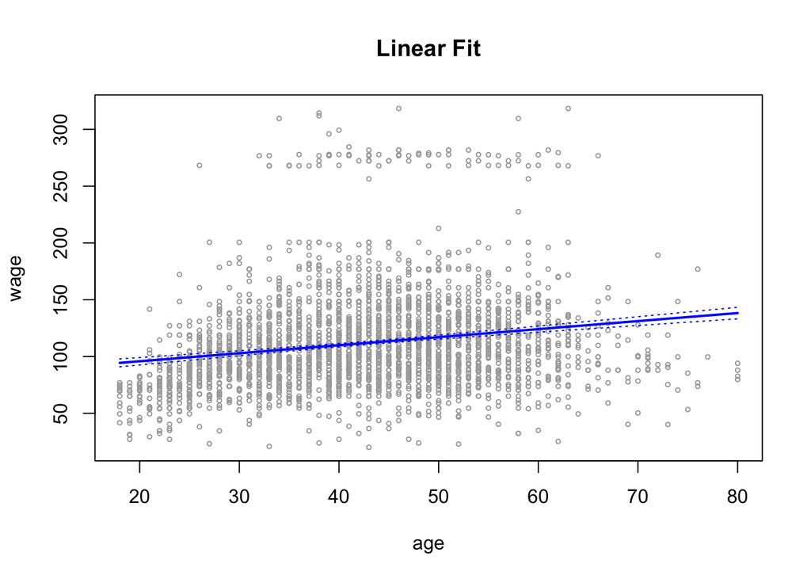

```r
age.grid=seq(range(age)[1],range(age)[2],by=0.5)
preds=predict(m_linear,list(age=age.grid),se=T)
se.bands=cbind(preds$fit +2* preds$se.fit ,preds$fit -2* preds$se.fit)
plot(age ,wage ,xlim=range(age.grid) ,cex =.5, col =" darkgrey ",main='Linear Fit')
lines(age.grid,preds$fit ,lwd =2, col =" blue")
matlines (age.grid ,se.bands ,lwd =1, col =" blue",lty =3)
```

As usual, we know how to hard code it…

```r
X <- cbind(1,age)
N <- nrow(X)
beta_manual <- c(solve(crossprod(X), crossprod(X, wage)))
res_manual <- c(X%*%beta_manual)-wage
Cov_beta <- sum(res_manual^2)/(N-2)*solve(crossprod(X))
X_grid <- cbind(1,age.grid)
preds_manual_fit <- c(X_grid%*%beta_manual)
preds_manual_fit_se <- sqrt(sapply(1:nrow(X_grid), function(i) t(X_grid[i,])%*%Cov_beta%*%X_grid[i,]))
```

Not very good eh?

## Polynomial Regression

The simplest way to extend linear regression to a nonlinear one is to employ polynomial functions. Let us try to add terms to the standard linear model:

```r
m_quad=lm(wage ~ age + I(age^2))
summary(m_quad)
```

```
##
## Call:
## lm(formula = wage ~ age + I(age^2))
##
## Residuals:
##     Min      1Q  Median      3Q     Max
## -99.126 -24.309  -5.017  15.494 205.621
##
## Coefficients:
##               Estimate Std. Error t value Pr(>|t|)
## (Intercept) -10.425224   8.189780  -1.273    0.203
## age           5.294030   0.388689  13.620   <2e-16 ***
## I(age^2)     -0.053005   0.004432 -11.960   <2e-16 ***
## ---
## Signif. codes:  0 '***' 0.001 '**' 0.01 '*' 0.05 '.' 0.1 ' ' 1
##
## Residual standard error: 39.99 on 2997 degrees of freedom
## Multiple R-squared:  0.08209,    Adjusted R-squared:  0.08147
## F-statistic:   134 on 2 and 2997 DF,  p-value: < 2.2e-16
```

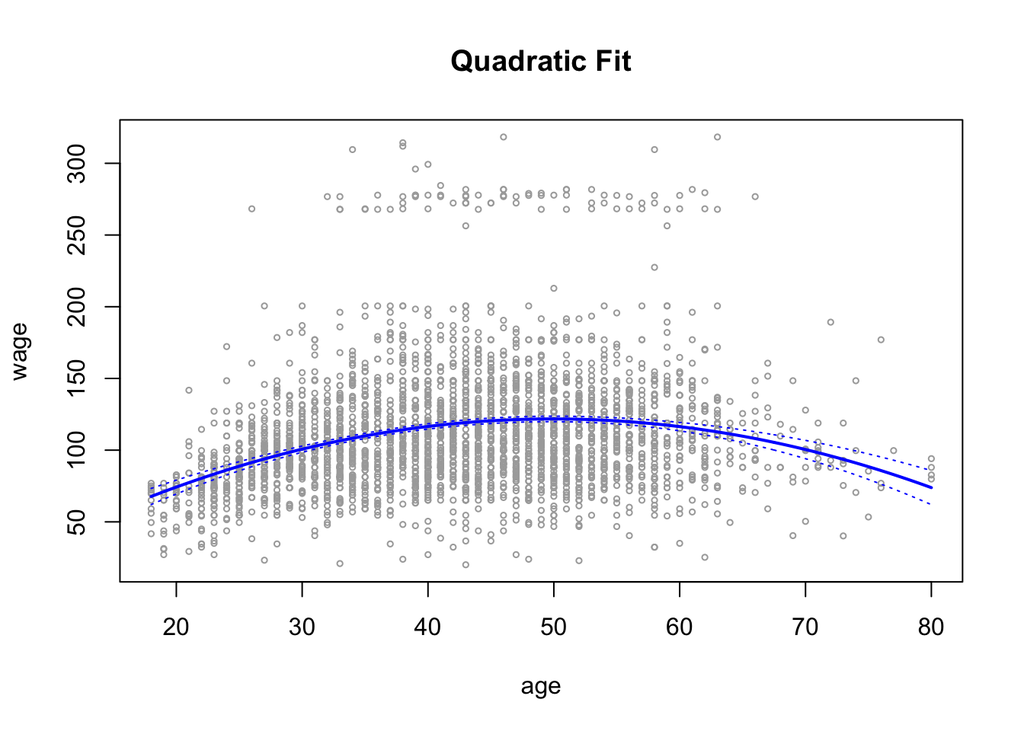

```r
preds=predict(m_quad,list(age=age.grid),se=T)
se.bands=cbind(preds$fit +2* preds$se.fit ,preds$fit -2* preds$se.fit)
plot(age ,wage ,xlim=range(age.grid) ,cex =.5, col =" darkgrey ",main='Quadratic Fit')
lines(age.grid,preds$fit ,lwd =2, col =" blue")
matlines (age.grid ,se.bands ,lwd =1, col =" blue",lty =3)
```

There is actually a more efficient way to do so (functional programming tip):

```r
m_list=lapply(1:10,function(degree){lm(wage ~ poly(age,degree=degree))})
do.call(anova,m_list)
```

|  | Res.Df | RSS | Df | Sum of Sq | F | Pr(>F) |
| --- | --- | --- | --- | --- | --- | --- |
| 1 | 2998 | 5022216 | NA | NA | NA | NA |
| 2 | 2997 | 4793430 | 1 | 2.287860e+05 | 1.437638e+02 | 2.187330e-32 |
| 3 | 2996 | 4777674 | 1 | 1.575569e+04 | 9.900512e+00 | 1.668583e-03 |
| 4 | 2995 | 4771604 | 1 | 6.070152e+03 | 3.814342e+00 | 5.090874e-02 |
| 5 | 2994 | 4770322 | 1 | 1.282563e+03 | 8.059328e-01 | 3.693978e-01 |
| 6 | 2993 | 4766389 | 1 | 3.932258e+03 | 2.470939e+00 | 1.160744e-01 |
| 7 | 2992 | 4763834 | 1 | 2.555281e+03 | 1.605679e+00 | 2.051989e-01 |
| 8 | 2991 | 4763707 | 1 | 1.266690e+02 | 7.959584e-02 | 7.778654e-01 |
| 9 | 2990 | 4756703 | 1 | 7.004317e+03 | 4.401350e+00 | 3.599425e-02 |
| 10 | 2989 | 4756701 | 1 | 2.637537e+00 | 1.657367e-03 | 9.675292e-01 |

I would get the very same results with non-orthogonal polynomials

```r
m_list_raw=lapply(1:10,function(degree){lm(wage ~ poly(age,degree=degree,raw=T))})
do.call(what = anova,args = m_list)
```

|  | Res.Df | RSS | Df | Sum of Sq | F | Pr(>F) |
| --- | --- | --- | --- | --- | --- | --- |
| 1 | 2998 | 5022216 | NA | NA | NA | NA |
| 2 | 2997 | 4793430 | 1 | 2.287860e+05 | 1.437638e+02 | 2.187330e-32 |
| 3 | 2996 | 4777674 | 1 | 1.575569e+04 | 9.900512e+00 | 1.668583e-03 |
| 4 | 2995 | 4771604 | 1 | 6.070152e+03 | 3.814342e+00 | 5.090874e-02 |
| 5 | 2994 | 4770322 | 1 | 1.282563e+03 | 8.059328e-01 | 3.693978e-01 |
| 6 | 2993 | 4766389 | 1 | 3.932258e+03 | 2.470939e+00 | 1.160744e-01 |
| 7 | 2992 | 4763834 | 1 | 2.555281e+03 | 1.605679e+00 | 2.051989e-01 |
| 8 | 2991 | 4763707 | 1 | 1.266690e+02 | 7.959584e-02 | 7.778654e-01 |
| 9 | 2990 | 4756703 | 1 | 7.004317e+03 | 4.401350e+00 | 3.599425e-02 |
| 10 | 2989 | 4756701 | 1 | 2.637537e+00 | 1.657367e-03 | 9.675292e-01 |

While the manual derivation of non-orthogonal polynomials is straightforward, orthogonal ones are defined as powers of our original predictor that are mutually orthogonal.

```r
x <- Wage$age
ort_poly <- poly(x,degree=2)

# First manual orthogonal polynomial: x is centered and rescaled as to have unit length
manual_poly_1 <- (x-mean(x))/sqrt(sum((x-mean(x))^2))
all(abs(ort_poly[,1]-manual_poly_1)<1e16)
```

```
## [1] TRUE
```

```r
# Second manual orthogonal polynomial: obtained regressing x^2 against the previous orthogonal polynomials,
# rescaling the residuals to be a vector of unit length

manual_poly_lm_2 <- lm(x^2~manual_poly_1)
manual_poly_2 <- manual_poly_lm_2$residuals/sqrt(sum(manual_poly_lm_2$residuals^2))
all(abs(ort_poly[,2]-manual_poly_2)<1e16)
```

```
## [1] TRUE
```

And so on. In general, orthogonal polynomials are preferred in regression as the situation gets badly messed up if I try classic t-test based model selection:

```r
summary(m_list[[5]])
```

```
##
## Call:
## lm(formula = wage ~ poly(age, degree = degree))
##
## Residuals:
##     Min      1Q  Median      3Q     Max
## -99.049 -24.386  -5.028  15.344 202.886
##
## Coefficients:
##                              Estimate Std. Error t value Pr(>|t|)
## (Intercept)                  111.7036     0.7288 153.278  < 2e-16 ***
## poly(age, degree = degree)1  447.0679    39.9161  11.200  < 2e-16 ***
## poly(age, degree = degree)2 -478.3158    39.9161 -11.983  < 2e-16 ***
## poly(age, degree = degree)3  125.5217    39.9161   3.145  0.00168 **
## poly(age, degree = degree)4  -77.9112    39.9161  -1.952  0.05105 .
## poly(age, degree = degree)5  -35.8129    39.9161  -0.897  0.36968
## ---
## Signif. codes:  0 '***' 0.001 '**' 0.01 '*' 0.05 '.' 0.1 ' ' 1
##
## Residual standard error: 39.92 on 2994 degrees of freedom
## Multiple R-squared:  0.08651,    Adjusted R-squared:  0.08498
## F-statistic: 56.71 on 5 and 2994 DF,  p-value: < 2.2e-16
```

```r
summary(m_list[[4]])
```

```
##
## Call:
## lm(formula = wage ~ poly(age, degree = degree))
##
## Residuals:
##     Min      1Q  Median      3Q     Max
## -98.707 -24.626  -4.993  15.217 203.693
##
## Coefficients:
##                              Estimate Std. Error t value Pr(>|t|)
## (Intercept)                  111.7036     0.7287 153.283  < 2e-16 ***
## poly(age, degree = degree)1  447.0679    39.9148  11.201  < 2e-16 ***
## poly(age, degree = degree)2 -478.3158    39.9148 -11.983  < 2e-16 ***
## poly(age, degree = degree)3  125.5217    39.9148   3.145  0.00168 **
## poly(age, degree = degree)4  -77.9112    39.9148  -1.952  0.05104 .
## ---
## Signif. codes:  0 '***' 0.001 '**' 0.01 '*' 0.05 '.' 0.1 ' ' 1
##
## Residual standard error: 39.91 on 2995 degrees of freedom
## Multiple R-squared:  0.08626,    Adjusted R-squared:  0.08504
## F-statistic: 70.69 on 4 and 2995 DF,  p-value: < 2.2e-16
```

```r
summary(m_list[[3]])
```

```
##
## Call:
## lm(formula = wage ~ poly(age, degree = degree))
##
## Residuals:
##     Min      1Q  Median      3Q     Max
## -99.693 -24.562  -5.222  15.096 206.119
##
## Coefficients:
##                              Estimate Std. Error t value Pr(>|t|)
## (Intercept)                  111.7036     0.7291 153.211  < 2e-16 ***
## poly(age, degree = degree)1  447.0679    39.9335  11.195  < 2e-16 ***
## poly(age, degree = degree)2 -478.3158    39.9335 -11.978  < 2e-16 ***
## poly(age, degree = degree)3  125.5217    39.9335   3.143  0.00169 **
## ---
## Signif. codes:  0 '***' 0.001 '**' 0.01 '*' 0.05 '.' 0.1 ' ' 1
##
## Residual standard error: 39.93 on 2996 degrees of freedom
## Multiple R-squared:  0.0851, Adjusted R-squared:  0.08419
## F-statistic: 92.89 on 3 and 2996 DF,  p-value: < 2.2e-16
```

vs (look at the p-values)

```r
summary(m_list_raw[[5]])
```

```
##
## Call:
## lm(formula = wage ~ poly(age, degree = degree, raw = T))
##
## Residuals:
##     Min      1Q  Median      3Q     Max
## -99.049 -24.386  -5.028  15.344 202.886
##
## Coefficients:
##                                        Estimate Std. Error t value Pr(>|t|)
## (Intercept)                          -4.970e+01  1.614e+02  -0.308    0.758
## poly(age, degree = degree, raw = T)1  3.993e+00  2.011e+01   0.199    0.843
## poly(age, degree = degree, raw = T)2  2.760e-01  9.585e-01   0.288    0.773
## poly(age, degree = degree, raw = T)3 -1.265e-02  2.191e-02  -0.577    0.564
## poly(age, degree = degree, raw = T)4  1.835e-04  2.408e-04   0.762    0.446
## poly(age, degree = degree, raw = T)5 -9.157e-07  1.021e-06  -0.897    0.370
##
## Residual standard error: 39.92 on 2994 degrees of freedom
## Multiple R-squared:  0.08651,    Adjusted R-squared:  0.08498
## F-statistic: 56.71 on 5 and 2994 DF,  p-value: < 2.2e-16
```

```r
summary(m_list_raw[[4]])
```

```
##
## Call:
## lm(formula = wage ~ poly(age, degree = degree, raw = T))
##
## Residuals:
##     Min      1Q  Median      3Q     Max
## -98.707 -24.626  -4.993  15.217 203.693
##
## Coefficients:
##                                        Estimate Std. Error t value Pr(>|t|)
## (Intercept)                          -1.842e+02  6.004e+01  -3.067 0.002180 **
## poly(age, degree = degree, raw = T)1  2.125e+01  5.887e+00   3.609 0.000312 ***
## poly(age, degree = degree, raw = T)2 -5.639e-01  2.061e-01  -2.736 0.006261 **
## poly(age, degree = degree, raw = T)3  6.811e-03  3.066e-03   2.221 0.026398 *
## poly(age, degree = degree, raw = T)4 -3.204e-05  1.641e-05  -1.952 0.051039 .
## ---
## Signif. codes:  0 '***' 0.001 '**' 0.01 '*' 0.05 '.' 0.1 ' ' 1
##
## Residual standard error: 39.91 on 2995 degrees of freedom
## Multiple R-squared:  0.08626,    Adjusted R-squared:  0.08504
## F-statistic: 70.69 on 4 and 2995 DF,  p-value: < 2.2e-16
```

```r
summary(m_list_raw[[3]])
```

```
##
## Call:
## lm(formula = wage ~ poly(age, degree = degree, raw = T))
##
## Residuals:
##     Min      1Q  Median      3Q     Max
## -99.693 -24.562  -5.222  15.096 206.119
##
## Coefficients:
##                                        Estimate Std. Error t value Pr(>|t|)
## (Intercept)                          -7.524e+01  2.218e+01  -3.392 0.000703 ***
## poly(age, degree = degree, raw = T)1  1.019e+01  1.605e+00   6.348 2.51e-10 ***
## poly(age, degree = degree, raw = T)2 -1.680e-01  3.686e-02  -4.559 5.36e-06 ***
## poly(age, degree = degree, raw = T)3  8.495e-04  2.702e-04   3.143 0.001687 **
## ---
## Signif. codes:  0 '***' 0.001 '**' 0.01 '*' 0.05 '.' 0.1 ' ' 1
##
## Residual standard error: 39.93 on 2996 degrees of freedom
## Multiple R-squared:  0.0851, Adjusted R-squared:  0.08419
## F-statistic: 92.89 on 3 and 2996 DF,  p-value: < 2.2e-16
```

All in all, the correct model seems to be a fourth degree polynomial. Let us look at some diagnostics:

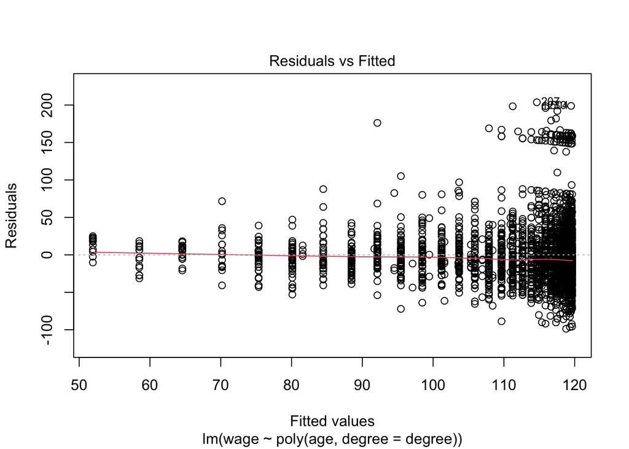

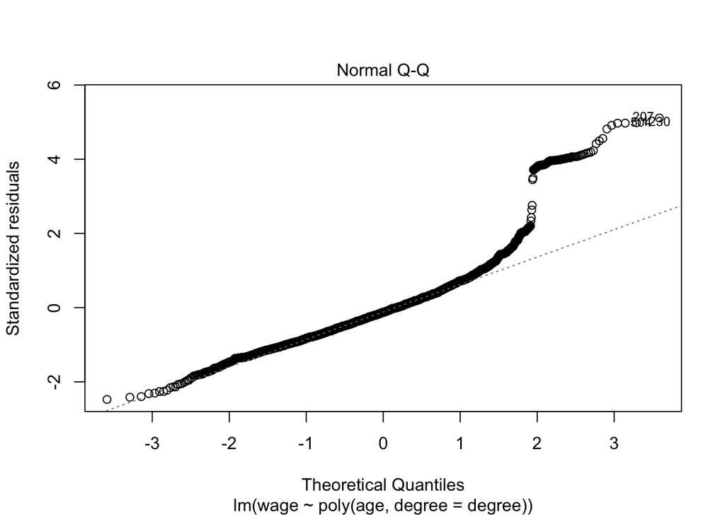

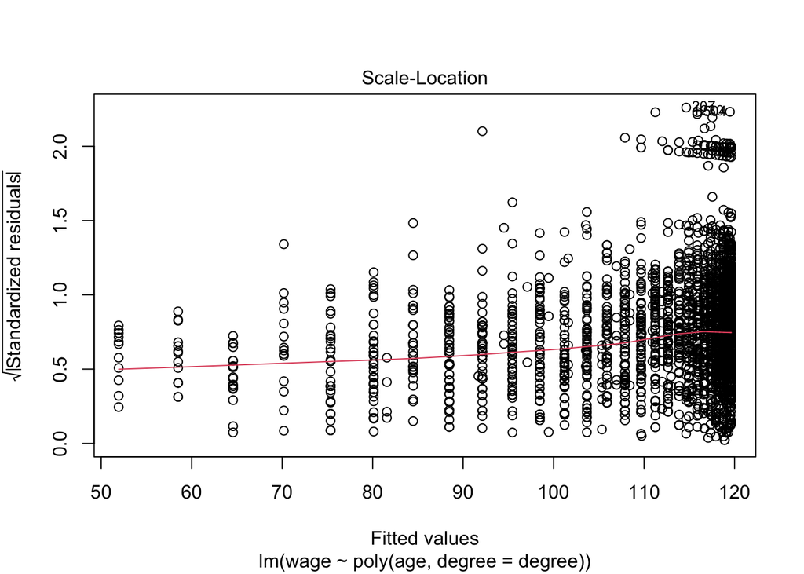

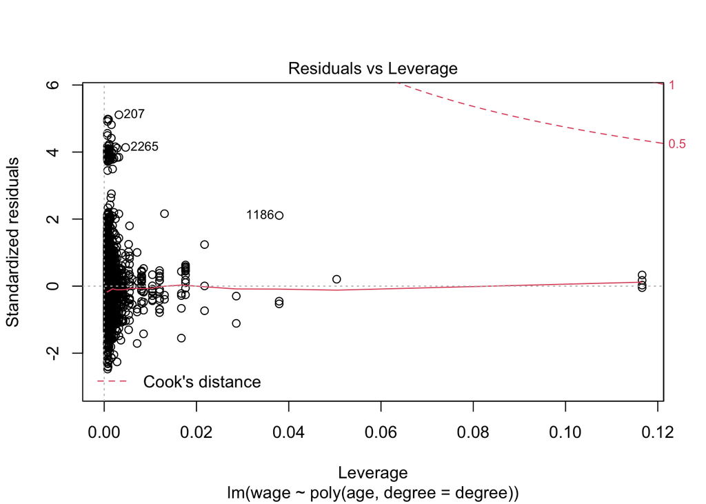

```r
plot(m_list[[4]])
```

```r
lm_4 <- m_list[[4]]
N <- length(age)
# 1
plot(x=lm_4$fitted.values,y=lm_4$residuals)

# 2
plot(qnorm(ppoints(n = N)),sort(rstandard(lm_4)))
abline(a = 0,b = 1,col="red")

# 3
plot(lm_4$fitted.values,sqrt(abs(rstandard(lm_4))))

# 4
#XX <- model.matrix(lm_4)
#diag(XX%*%solve(t(XX)%*%XX)%*%t(XX)))
plot(hatvalues(lm_4),sqrt(abs(rstandard(lm_4))))
```

Still some of the upper points are not well captured by the model, let us try to make predictions

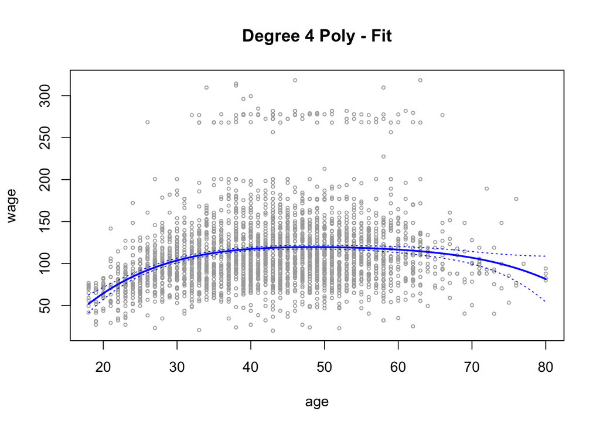

```r
preds=predict(m_list[[4]],list(age=age.grid),se=T)
se.bands=cbind(preds$fit +2* preds$se.fit ,preds$fit -2* preds$se.fit)
plot(age ,wage ,xlim=range(age.grid) ,cex =.5, col =" darkgrey ",main='Degree 4 Poly - Fit')
lines(age.grid,preds$fit ,lwd =2, col =" blue")
matlines (age.grid ,se.bands ,lwd =1, col =" blue",lty =3)
```

What happens, instead, if I try to overfit?

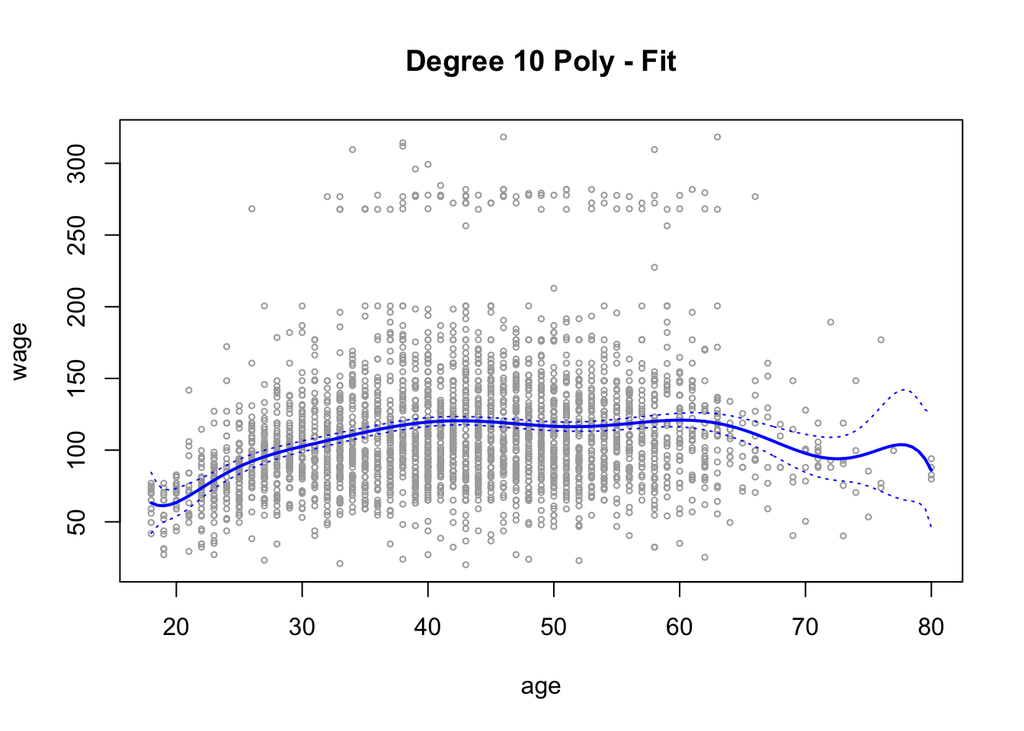

```r
preds=predict(m_list[[10]],list(age=age.grid),se=T)
se.bands=cbind(preds$fit +2* preds$se.fit ,preds$fit -2* preds$se.fit)
plot(age ,wage ,xlim=range(age.grid) ,cex =.5, col =" darkgrey ",main='Degree 10 Poly - Fit')
lines(age.grid,preds$fit ,lwd =2, col =" blue")
matlines (age.grid ,se.bands ,lwd =1, col =" blue",lty =3)
```

Notice that polynomial regression can be directly applied to GLMs: consider the following logistic regression models

```r
m_list_logit=lapply(1:5,function(degree){glm(I(wage>250) ~ poly(age,degree=degree),family='binomial')})
do.call(what = anova, c(list(test="Chisq"), m_list_logit))
```

|  | Resid. Df | Resid. Dev | Df | Deviance | Pr(>Chi) |
| --- | --- | --- | --- | --- | --- |
| 1 | 2998 | 719.2285 | NA | NA | NA |
| 2 | 2997 | 709.0237 | 1 | 10.204766 | 0.001400782 |
| 3 | 2996 | 707.9215 | 1 | 1.102191 | 0.293785708 |
| 4 | 2995 | 701.2198 | 1 | 6.701683 | 0.009632195 |
| 5 | 2994 | 698.8699 | 1 | 2.349930 | 0.125288656 |

A smaller model here may suffice

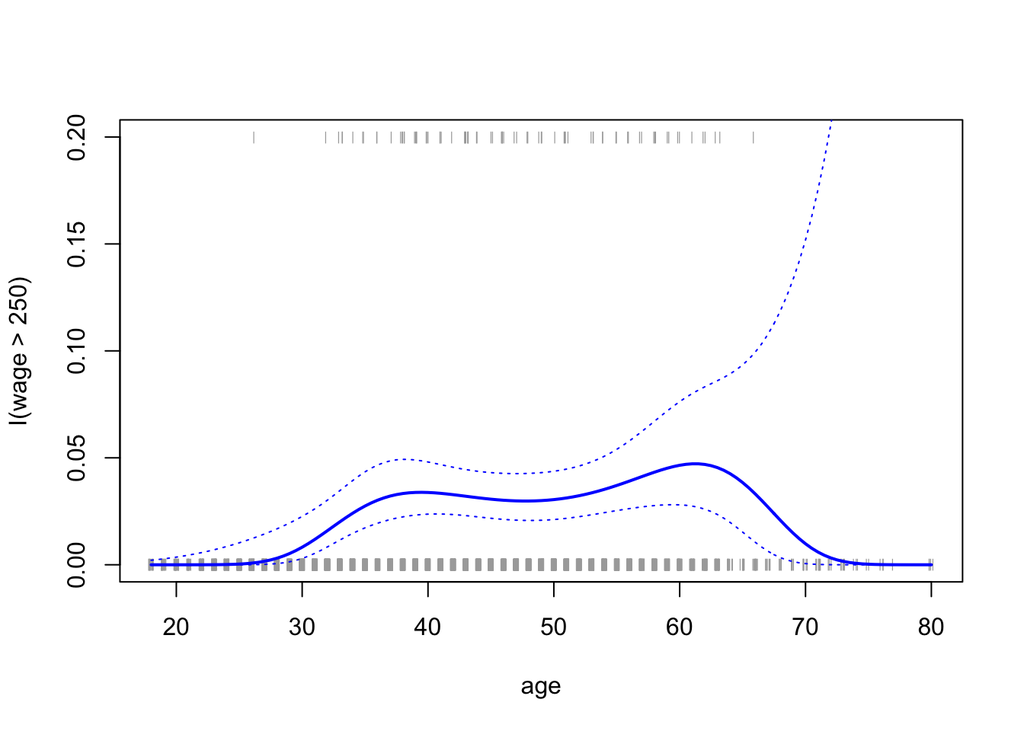

```r
preds=predict(m_list_logit[[4]],list(age=age.grid),se=T)
pfit=exp(preds$fit )/(1+ exp( preds$fit ))
se.bands.logit = cbind(preds$fit +2* preds$se.fit , preds$fit -2*
                         preds$se.fit)
se.bands = exp(se.bands.logit)/(1+ exp(se.bands.logit))
plot(age ,I(wage >250) ,xlim=range(age.grid) ,type ="n",ylim=c(0 ,.2) )
points (jitter (age), I((wage >250) /5) ,cex =.5, pch ="|",
          col =" darkgrey ", main='Poly 4 Fit - Logistic')
lines(age.grid ,pfit ,lwd =2, col =" blue")
matlines (age.grid ,se.bands ,lwd =1, col =" blue",lty =3)
```

### Exercise

Considering the prestige and income variables from the Prestige of Canadian Occupations dataset, build polynomial regression models to explain prestige as a (non-linear) function of income

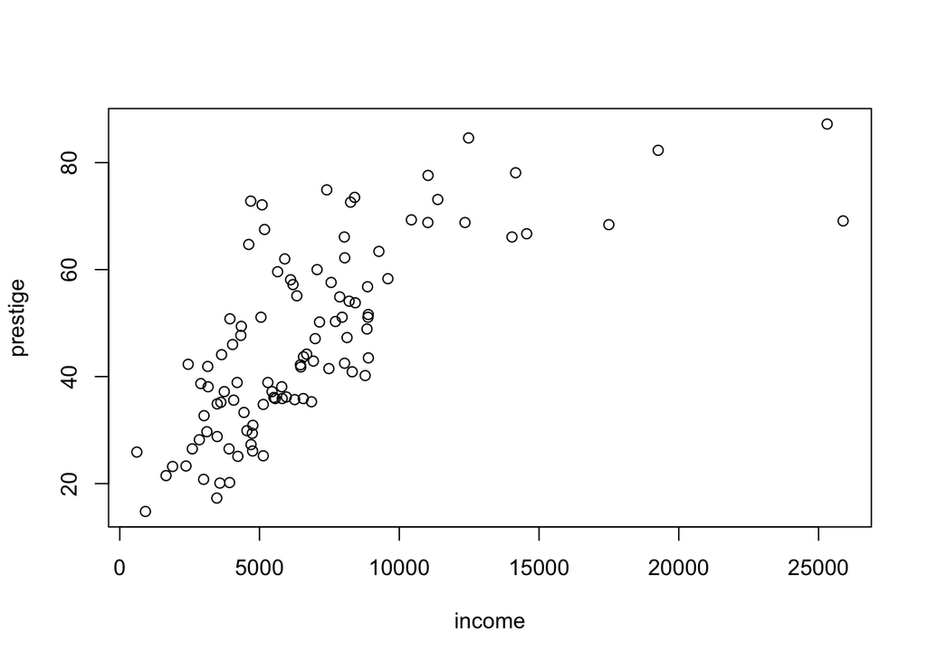

```r
with(Prestige,plot(income,prestige))
```

- Is a linear function sufficient to model the relationship between the two variables?
- Which degree is sufficient to consider for modeling the relationship?

## Step regression

Using polynomial functions of the features as predictors in a linear model imposes a global structure on the non-linear function of X. We can instead use step regression in order to avoid imposing such a global structure. The idea is to break the range of X into bins, and fit a different constant in each bin. This amounts to converting a continuous variable into an ordered categorical variable. Notice that, same as for polynomials regression, the fitting procedure remains exactly equal to the one used for linear models: we are still always using OLS here! Let us keep working with the Prestige dataset and split the feature space X in two bins. Ah, in case you have not noticed during the exercise, a linear model is too restrictive here:

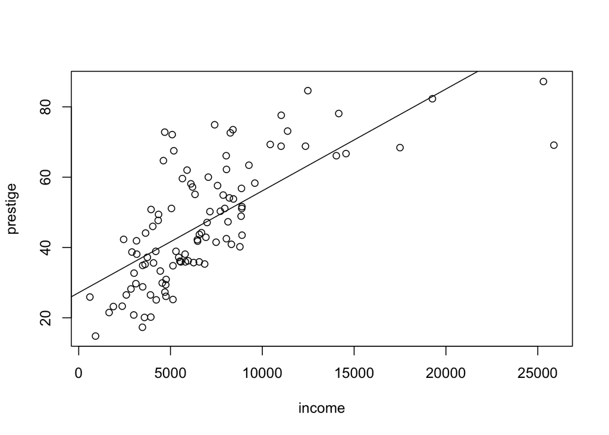

```r
with(Prestige,plot(income,prestige))
abline(lm(prestige~income, data=Prestige))
```

Cutpoint maybe around $10000$? How do we do that?

```r
head(Prestige$income)
```

```
## [1] 12351 25879  9271  8865  8403 11030
```

```r
head(with(Prestige, cut(income,breaks = c(min(income),10000,max(income)))))
```

```
## [1] (1e+04,2.59e+04] (1e+04,2.59e+04] (611,1e+04]      (611,1e+04]
## [5] (611,1e+04]      (1e+04,2.59e+04]
## Levels: (611,1e+04] (1e+04,2.59e+04]
```

Then it boils down to fit an lm with this new variable

```r
m_cut=lm(prestige ~ cut(income,breaks = c(-Inf,10000,max(income))), data=Prestige)
broom::tidy(summary(m_cut)) %>%
  dplyr::mutate(term=ifelse(term=="(Intercept)",term, "income_cut(1e+04,2.59e+04]")) # all this mess to have a nice name on the summary table
```

| term | estimate | std.error | statistic | p.value |
| --- | --- | --- | --- | --- |
| (Intercept) | 42.88652 | 1.461784 | 29.338473 | 6.220111e-51 |
| income_cut(1e+04,2.59e+04] | 30.96733 | 4.094602 | 7.562965 | 1.953531e-11 |

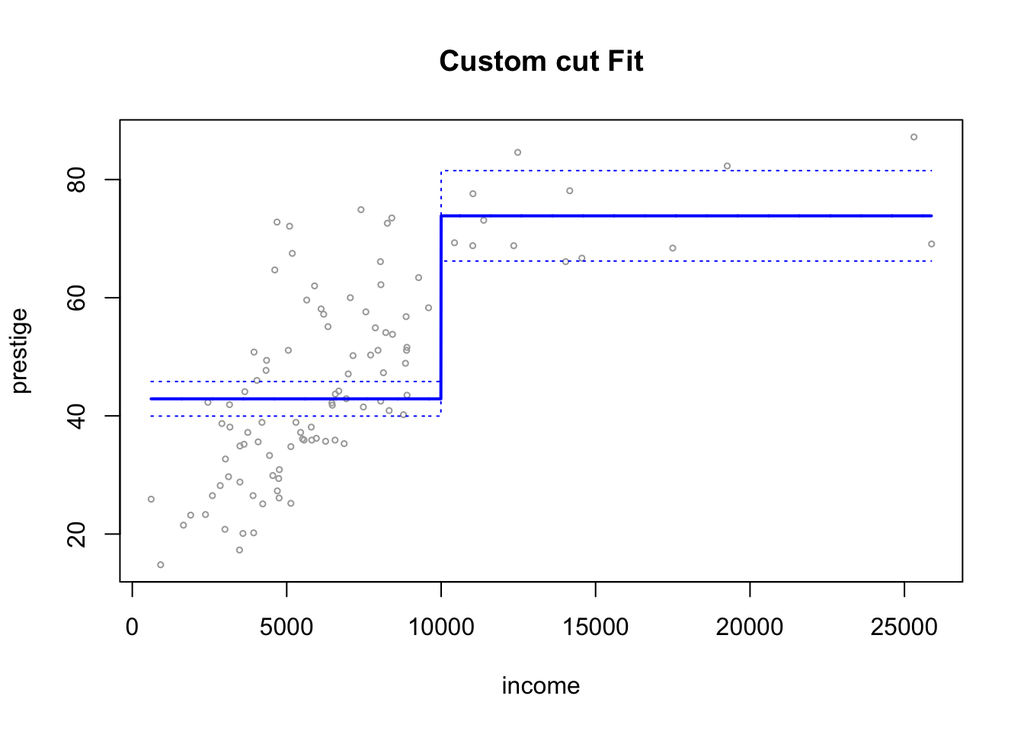

```r
income.grid=with(Prestige, seq(range(income)[1],range(income)[2],by=10))
preds=predict(m_cut,list(income=income.grid),se=T)
se.bands=cbind(preds$fit +2* preds$se.fit ,preds$fit -2* preds$se.fit)
with(Prestige, plot(income ,prestige ,xlim=range(income.grid) ,cex =.5, col =" darkgrey ",main='Custom cut Fit'))
lines(income.grid,preds$fit ,lwd =2, col =" blue")
matlines(income.grid ,se.bands ,lwd =1, col =" blue",lty =3)
```

Of course we can be even more flexible

```r
m_cut=lm(prestige ~ cut(income,breaks=4),data = Prestige)
```

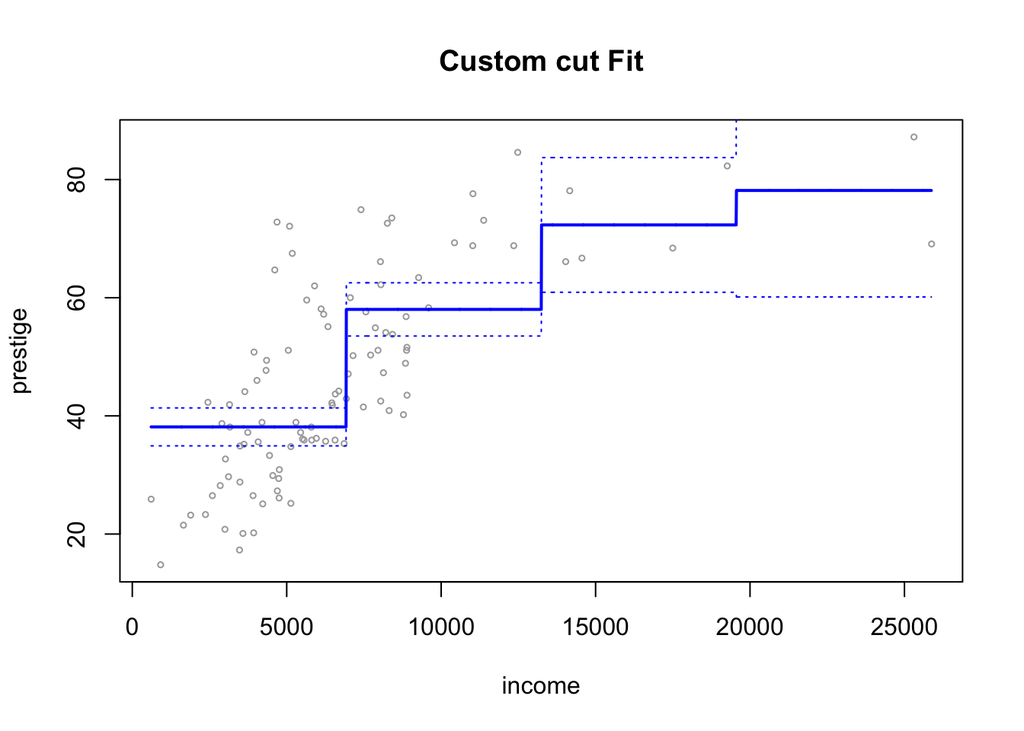

```r
income.grid=with(Prestige, seq(range(income)[1],range(income)[2],by=10))
preds=predict(m_cut,list(income=income.grid),se=T)
se.bands=cbind(preds$fit +2* preds$se.fit ,preds$fit -2* preds$se.fit)
with(Prestige, plot(income ,prestige ,xlim=range(income.grid) ,cex =.5, col =" darkgrey ",main='Custom cut Fit'))
lines(income.grid,preds$fit ,lwd =2, col =" blue")
matlines(income.grid ,se.bands ,lwd =1, col =" blue",lty =3)
```

Or we may want to have uneven bins

```r
uneven_breaks <- c(seq(0,10000,by=1000),seq(15000,35000,by=10000))
```

```r
m_cut=lm(prestige ~ cut(income,breaks=uneven_breaks),data = Prestige)
```

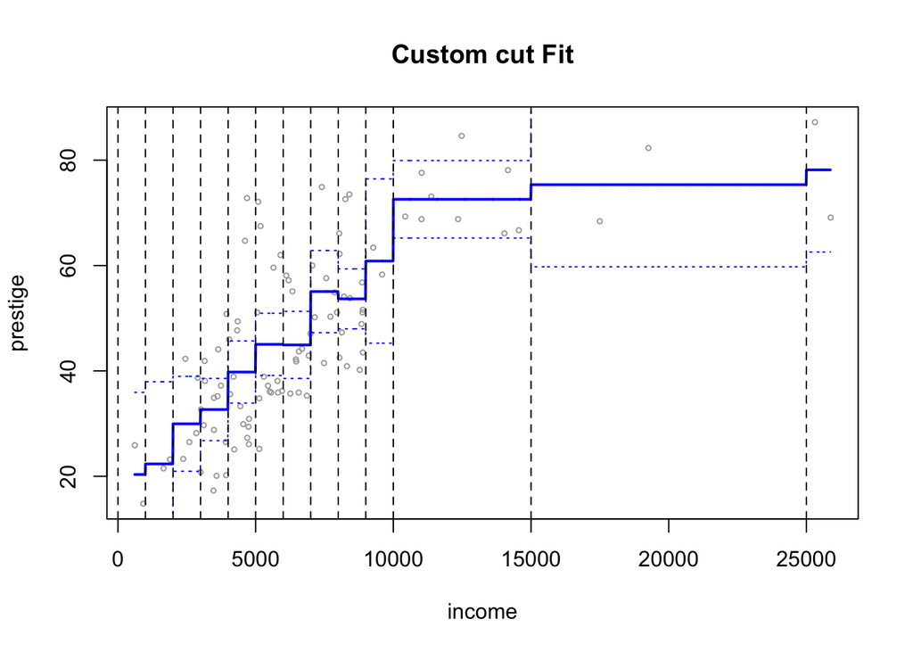

```r
income.grid=with(Prestige, seq(range(income)[1],range(income)[2],by=10))
preds=predict(m_cut,list(income=income.grid),se=T)
se.bands=cbind(preds$fit +2* preds$se.fit ,preds$fit -2* preds$se.fit)
with(Prestige, plot(income ,prestige ,xlim=range(income.grid) ,cex =.5, col =" darkgrey ",main='Custom cut Fit'))
lines(income.grid,preds$fit ,lwd =2, col =" blue")
matlines(income.grid ,se.bands ,lwd =1, col =" blue",lty =3)
abline(v=uneven_breaks,lty=2)
```

```r
summary(m_cut)
```

```
##
## Call:
## lm(formula = prestige ~ cut(income, breaks = uneven_breaks),
##     data = Prestige)
##
## Residuals:
##     Min      1Q  Median      3Q     Max
## -19.843  -7.620  -2.312   5.930  33.007
##
## Coefficients:
##                                                      Estimate Std. Error
## (Intercept)                                            20.350      7.795
## cut(income, breaks = uneven_breaks)(1e+03,2e+03]        2.000     11.024
## cut(income, breaks = uneven_breaks)(2e+03,3e+03]        9.617      9.001
## cut(income, breaks = uneven_breaks)(3e+03,4e+03]       12.329      8.333
## cut(income, breaks = uneven_breaks)(4e+03,5e+03]       19.443      8.333
## cut(income, breaks = uneven_breaks)(5e+03,6e+03]       24.693      8.333
## cut(income, breaks = uneven_breaks)(6e+03,7e+03]       24.583      8.420
## cut(income, breaks = uneven_breaks)(7e+03,8e+03]       34.713      8.715
## cut(income, breaks = uneven_breaks)(8e+03,9e+03]       33.323      8.298
## cut(income, breaks = uneven_breaks)(9e+03,1e+04]       40.500     11.024
## cut(income, breaks = uneven_breaks)(1e+04,1.5e+04]     52.217      8.618
## cut(income, breaks = uneven_breaks)(1.5e+04,2.5e+04]   55.000     11.024
## cut(income, breaks = uneven_breaks)(2.5e+04,3.5e+04]   57.800     11.024
##                                                      t value Pr(>|t|)
## (Intercept)                                            2.611 0.010603 *
## cut(income, breaks = uneven_breaks)(1e+03,2e+03]       0.181 0.856446
## cut(income, breaks = uneven_breaks)(2e+03,3e+03]       1.068 0.288222
## cut(income, breaks = uneven_breaks)(3e+03,4e+03]       1.479 0.142550
## cut(income, breaks = uneven_breaks)(4e+03,5e+03]       2.333 0.021893 *
## cut(income, breaks = uneven_breaks)(5e+03,6e+03]       2.963 0.003905 **
## cut(income, breaks = uneven_breaks)(6e+03,7e+03]       2.920 0.004436 **
## cut(income, breaks = uneven_breaks)(7e+03,8e+03]       3.983 0.000139 ***
## cut(income, breaks = uneven_breaks)(8e+03,9e+03]       4.016 0.000124 ***
## cut(income, breaks = uneven_breaks)(9e+03,1e+04]       3.674 0.000408 ***
## cut(income, breaks = uneven_breaks)(1e+04,1.5e+04]     6.059 3.22e-08 ***
## cut(income, breaks = uneven_breaks)(1.5e+04,2.5e+04]   4.989 2.98e-06 ***
## cut(income, breaks = uneven_breaks)(2.5e+04,3.5e+04]   5.243 1.05e-06 ***
## ---
## Signif. codes:  0 '***' 0.001 '**' 0.01 '*' 0.05 '.' 0.1 ' ' 1
##
## Residual standard error: 11.02 on 89 degrees of freedom
## Multiple R-squared:  0.6382, Adjusted R-squared:  0.5894
## F-statistic: 13.08 on 12 and 89 DF,  p-value: 5.088e-15
```

### Exercise

Are you able to provide a step regression model with an $R^2>0.8$? What do you think? Is it a good model? Can it be used to make predictions?